# Hypertension in adults aged 30 and over in Bharatpur, Nepal

Dataset 3: Nepal hypertension and cardiovascular risk-factor survey

RSR feasibility analysis

2026-08-03

# Introduction

This is a community-based cross-sectional survey of adults aged 30 years and over living in Bharatpur, Chitwan district, Nepal, carried out to estimate the prevalence of hypertension and identify its risk factors (Dhungana and colleagues, *PLOS ONE* 2016, e0185806). Blood pressure was measured twice with a digital device and averaged, the WHO STEPS instrument supplied the behavioural information, and height and weight were measured directly. Hypertension is the outcome the survey was designed around, and at 38.9% prevalence it is a substantial burden for a population that is largely undiagnosed and untreated.

**Aim.** Among adults aged 30 and over in Bharatpur, we examined which of sex, age band, education, occupation, poverty, smoking, smokeless tobacco, alcohol, fruit and vegetable intake, salt intake, physical activity, family history of hypertension and body mass index are independently associated with the odds of being hypertensive, mutually adjusting for the others.

This is a *Purpose 3* analysis: several predictors are of interest and the question is which remain associated with the outcome after mutual adjustment.

# Methods

**Data source.** A cross-sectional survey of 1159 adults aged 30 years and over resident in Bharatpur Municipality, Chitwan, Nepal. The source study used multistage cluster sampling: four wards were selected at random and approximately 300 participants enrolled in each, with the sample size calculation assuming a design effect of 1.5. **The ward identifier is not in this extract** (see Limitations). Each row is one participant.

**Variables.** The outcome is `hypertension`, coded 1 (the event) if mean systolic pressure was at least 140 mmHg **or** mean diastolic pressure at least 90 mmHg **or** the participant reported taking antihypertensive medication in the previous two weeks. There are 451 events among 1159 participants (38.9%). Predictors are sex (reference *Female*); age band in years (reference *30-39*; age was recorded only in four bands, so no odds ratio per year of age can be estimated); education (reference *None or informal*); main occupation (reference *Household work*); family income per head below the poverty line (reference *No*); smoking status (reference *Never*); current smokeless tobacco use (reference *No*); any alcohol in the last month (reference *No*); fruit and vegetable servings per day; estimated salt intake in g/day; physical activity level (reference *Moderate or high*); family history of hypertension (reference *No*); and body mass index in kg/m2.

**The exclusions matter more here than the inclusions.** Because `hypertension` is *defined* from `systolic_bp`, `diastolic_bp` and `antihypertensive_drug`, none of those three can be a predictor: they are components of the outcome, not risk factors for it. `antihypertensive_drug` is the extreme case – every one of the 131 treated participants is hypertensive by definition, so it separates the outcome perfectly and the model will not converge to a finite coefficient. `bp_awareness` is only slightly less circular: having been told you have raised blood pressure is a consequence of having it, and in this file every one of the 241 participants who are aware is hypertensive, while 210 hypertensive participants are unaware. Awareness therefore predicts the outcome perfectly in one direction, which is complete separation (see Diagnostics for the fitted coefficient). It is excluded on causal grounds first, but it would also break the model. Two further pairs measure the same construct twice and only one of each may enter: `physical_activity` is a deterministic cut of `mets_min_per_week` at 600 MET-minutes per week (the “Low” group spans 0-600 and “Moderate or high” spans 620-29,260), and the categorical version is used because it is the WHO STEPS classification the source paper reports; and `cigarettes_per_week` is zero for every never-smoker, so `smoking_status` is used instead because it also separates former from never smokers.

**Statistical analysis.** Logistic regression via `glm(family = binomial)`, justified because the outcome is binary; the event modelled is being hypertensive. We fitted a univariable model for each predictor first, then a single multivariable model containing all of them. Predictors were chosen in advance on subject-matter grounds, not by significance. Estimates are reported as odds ratios with 95% confidence intervals; significance threshold 0.05. Model adequacy was assessed with AIC, Tjur’s R-squared, events per parameter and `performance::check_model()`. Analysis used R version 4.6.0 (2026-04-24) with tidyverse, gtsummary and performance.

**Missing data.** Complete-case analysis: 1159 of 1159 rows were analysed (0 dropped). Every variable in this file is 100% complete, so listwise deletion removes no rows at all. There is no missing-data story: no imputation, no complete-case selection bias, and the full event count is available to the model.

# Results

## Sample characteristics

**Table 1. Sample characteristics by hypertension status.**

| **Characteristic** | **N** | **Overall** N = 1,159<sup>1</sup> | **No** N = 708<sup>1</sup> | **Yes** N = 451<sup>1</sup> |
| --- | --- | --- | --- | --- |
| Sex | 1,159 |  |  |  |
| Female |  | 824 (71%) | 534 (75%) | 290 (64%) |
| Male |  | 335 (29%) | 174 (25%) | 161 (36%) |
| Age band (years) | 1,159 |  |  |  |
| 30-39 |  | 383 (33%) | 300 (42%) | 83 (18%) |
| 40-49 |  | 295 (25%) | 185 (26%) | 110 (24%) |
| 50-59 |  | 218 (19%) | 116 (16%) | 102 (23%) |
| 60 or more |  | 263 (23%) | 107 (15%) | 156 (35%) |
| Education | 1,159 |  |  |  |
| None or informal |  | 626 (54%) | 336 (47%) | 290 (64%) |
| Primary |  | 136 (12%) | 92 (13%) | 44 (9.8%) |
| Secondary |  | 239 (21%) | 170 (24%) | 69 (15%) |
| Higher |  | 158 (14%) | 110 (16%) | 48 (11%) |
| Main occupation | 1,159 |  |  |  |
| Household work |  | 659 (57%) | 412 (58%) | 247 (55%) |
| Agriculture or labour |  | 142 (12%) | 89 (13%) | 53 (12%) |
| Job or self-employed |  | 305 (26%) | 185 (26%) | 120 (27%) |
| Unemployed |  | 53 (4.6%) | 22 (3.1%) | 31 (6.9%) |
| Below poverty line | 1,159 | 316 (27%) | 177 (25%) | 139 (31%) |
| Smoking status | 1,159 |  |  |  |
| Never |  | 770 (66%) | 529 (75%) | 241 (53%) |
| Former |  | 180 (16%) | 64 (9.0%) | 116 (26%) |
| Current |  | 209 (18%) | 115 (16%) | 94 (21%) |
| Smokeless tobacco use | 1,159 | 139 (12%) | 71 (10%) | 68 (15%) |
| Alcohol in the last month | 1,159 | 177 (15%) | 77 (11%) | 100 (22%) |
| Fruit and vegetable servings per day | 1,159 | 2.29 (1.43, 3.14) | 2.29 (1.43, 3.14) | 2.43 (1.57, 3.29) |
| Salt intake (g/day) | 1,159 | 2.85 (1.90, 4.55) | 2.85 (1.90, 4.55) | 2.85 (1.90, 4.27) |
| Physical activity level | 1,159 |  |  |  |
| Moderate or high |  | 744 (64%) | 484 (68%) | 260 (58%) |
| Low |  | 415 (36%) | 224 (32%) | 191 (42%) |
| Family history of hypertension | 1,159 | 170 (15%) | 91 (13%) | 79 (18%) |
| Body mass index (kg/m2) | 1,159 | 23.6 (21.0, 26.4) | 22.8 (20.4, 25.6) | 24.6 (22.3, 27.4) |

<sup>1</sup> n (%); Median (Q1, Q3)

Overall prevalence was 38.9%, rising from 21.7% in the 30-39 band to 59.3% among those aged 60 or more. Hypertensive participants averaged 25 kg/m2 against 23.1 kg/m2 in the normotensive, and were more often male, less educated and more often former smokers. Note one consequence of the composite definition: 37 participants are counted as hypertensive purely because they take medication, despite having entirely normal measured readings on the day. They are correctly classified – treated hypertension is still hypertension – but they are the reason the outcome cannot be reconstructed from blood pressure alone.

## Exploratory figure

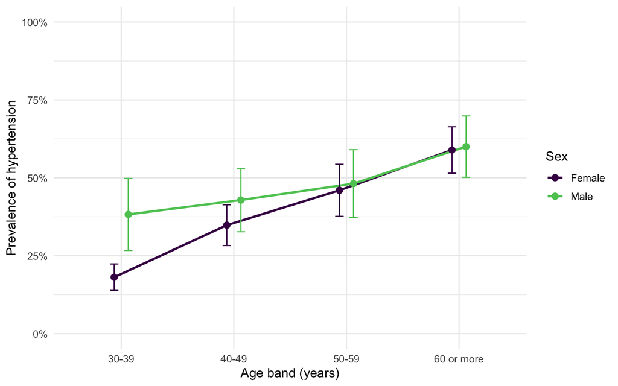

Figure 4. Prevalence of hypertension by age band and sex, with 95% Wilson confidence intervals.

Prevalence climbs steeply across the four age bands in both sexes, roughly tripling in women (18.1% to 58.9%) and rising less dramatically in men (38.2% to 60%). Men are above women in every band, but the gap is large only in the 30-39 group – where it also rests on just 68 men – and has essentially closed by age 60, so age is by far the dominant gradient and the sex effect is concentrated at younger ages.

## Univariable models

| **Characteristic** | **N** | **OR** | **95% CI** | **p-value** |
| --- | --- | --- | --- | --- |
| Sex | 1,159 |  |  |  |
| Female |  | — | — |  |
| Male |  | 1.70 | 1.32, 2.21 | <0.001 |
| Age band (years) | 1,159 |  |  |  |
| 30-39 |  | — | — |  |
| 40-49 |  | 2.15 | 1.53, 3.02 | <0.001 |
| 50-59 |  | 3.18 | 2.22, 4.57 | <0.001 |
| 60 or more |  | 5.27 | 3.74, 7.48 | <0.001 |
| Education | 1,159 |  |  |  |
| None or informal |  | — | — |  |
| Primary |  | 0.55 | 0.37, 0.82 | 0.003 |
| Secondary |  | 0.47 | 0.34, 0.65 | <0.001 |
| Higher |  | 0.51 | 0.35, 0.73 | <0.001 |
| Main occupation | 1,159 |  |  |  |
| Household work |  | — | — |  |
| Agriculture or labour |  | 0.99 | 0.68, 1.44 | >0.9 |
| Job or self-employed |  | 1.08 | 0.82, 1.43 | 0.6 |
| Unemployed |  | 2.35 | 1.34, 4.20 | 0.003 |
| Below poverty line | 1,159 |  |  |  |
| No |  | — | — |  |
| Yes |  | 1.34 | 1.03, 1.74 | 0.030 |
| Smoking status | 1,159 |  |  |  |
| Never |  | — | — |  |
| Former |  | 3.98 | 2.84, 5.62 | <0.001 |
| Current |  | 1.79 | 1.31, 2.45 | <0.001 |
| Smokeless tobacco use | 1,159 |  |  |  |
| No |  | — | — |  |
| Yes |  | 1.59 | 1.11, 2.27 | 0.010 |
| Alcohol in the last month | 1,159 |  |  |  |
| No |  | — | — |  |
| Yes |  | 2.33 | 1.69, 3.24 | <0.001 |
| Fruit and vegetable servings per day | 1,159 | 1.11 | 1.01, 1.21 | 0.036 |
| Salt intake (g/day) | 1,159 | 0.98 | 0.92, 1.03 | 0.4 |
| Physical activity level | 1,159 |  |  |  |
| Moderate or high |  | — | — |  |
| Low |  | 1.59 | 1.24, 2.03 | <0.001 |
| Family history of hypertension | 1,159 |  |  |  |
| No |  | — | — |  |
| Yes |  | 1.44 | 1.04, 2.00 | 0.029 |
| Body mass index (kg/m2) | 1,159 | 1.12 | 1.09, 1.16 | <0.001 |

Abbreviations: CI = Confidence Interval, OR = Odds Ratio

## Multivariable model

| **Characteristic** | **OR** | **95% CI** | **p-value** |
| --- | --- | --- | --- |
| Sex |  |  |  |
| Female | — | — |  |
| Male | 1.46 | 0.98, 2.17 | 0.061 |
| Age band (years) |  |  |  |
| 30-39 | — | — |  |
| 40-49 | 1.83 | 1.25, 2.69 | 0.002 |
| 50-59 | 2.52 | 1.65, 3.84 | <0.001 |
| 60 or more | 4.45 | 2.90, 6.90 | <0.001 |
| Education |  |  |  |
| None or informal | — | — |  |
| Primary | 0.63 | 0.39, 1.00 | 0.052 |
| Secondary | 0.57 | 0.38, 0.85 | 0.007 |
| Higher | 0.57 | 0.35, 0.94 | 0.028 |
| Main occupation |  |  |  |
| Household work | — | — |  |
| Agriculture or labour | 0.71 | 0.45, 1.13 | 0.2 |
| Job or self-employed | 1.10 | 0.75, 1.60 | 0.6 |
| Unemployed | 1.67 | 0.86, 3.29 | 0.13 |
| Below poverty line |  |  |  |
| No | — | — |  |
| Yes | 1.19 | 0.87, 1.62 | 0.3 |
| Smoking status |  |  |  |
| Never | — | — |  |
| Former | 2.92 | 1.98, 4.33 | <0.001 |
| Current | 1.35 | 0.90, 2.03 | 0.14 |
| Smokeless tobacco use |  |  |  |
| No | — | — |  |
| Yes | 1.06 | 0.65, 1.71 | 0.8 |
| Alcohol in the last month |  |  |  |
| No | — | — |  |
| Yes | 1.93 | 1.25, 2.99 | 0.003 |
| Fruit and vegetable servings per day | 1.17 | 1.05, 1.31 | 0.005 |
| Salt intake (g/day) | 1.01 | 0.95, 1.07 | 0.7 |
| Physical activity level |  |  |  |
| Moderate or high | — | — |  |
| Low | 1.29 | 0.97, 1.71 | 0.083 |
| Family history of hypertension |  |  |  |
| No | — | — |  |
| Yes | 1.21 | 0.83, 1.76 | 0.3 |
| Body mass index (kg/m2) | 1.17 | 1.13, 1.22 | <0.001 |

Abbreviations: CI = Confidence Interval, OR = Odds Ratio

Model fit

| Statistic | Value |
| --- | --- |
| AIC (full model) | 1309.400 |
| AIC (intercept only) | 1551.300 |
| Tjur's R-squared | 0.227 |
| Events (hypertensive) | 451.000 |
| Non-events | 708.000 |
| Model parameters (excluding intercept) | 20.000 |
| Events per parameter | 22.600 |

The full model has AIC 1309.4 against 1551.3 for an intercept-only model, a drop of 241.8, so the predictor set carries real information; Tjur’s R-squared is 0.227, meaning the average predicted probability differs by about 23 percentage points between hypertensive and normotensive participants. With 451 events and 20 non-intercept parameters there are 22.6 **events per parameter**, comfortably above the conventional minimum of 10, so the model is not overfitted and the coefficients are not the product of sparse cells.

Conditional on the other twelve predictors, the odds of hypertension are 4.45 times higher in those aged 60 or more than in the 30-39 band (95% CI 2.9 to 6.9); each additional kg/m2 of body mass index multiplies the odds by 1.174 (95% CI 1.133 to 1.218), that is 2.23-fold across 5 kg/m2; recent drinkers have 1.93 times the odds of non-drinkers (95% CI 1.25 to 2.99); and participants with secondary education have 0.57 times the odds of those with no or informal schooling (95% CI 0.38 to 0.85).

Two results need caution. Former smokers retain 2.92 times the odds of never-smokers (95% CI 1.98 to 4.33) while current smokers are not distinguishable from never-smokers (1.35, 95% CI 0.9 to 2.03). Read causally this would say quitting is dangerous; read as reverse causation it says people quit after being told they have high blood pressure, which is almost certainly what is happening in a cross-sectional survey where 241 participants already knew their diagnosis. Second, **fruit and vegetable servings** come out *positively* associated with hypertension (1.175 per serving, 95% CI 1.051 to 1.314, p = 0.005) – the wrong direction for any dietary story, and most plausibly either recall bias among people who know they are hypertensive and have been advised to eat more vegetables, or simple confounding by an unmeasured aspect of diet. It should not be reported as a finding.

## Unadjusted versus adjusted

**Table 2. Unadjusted and adjusted odds ratios.**

| **Characteristic** | **Unadjusted** **N** | **Unadjusted** **OR** | **Unadjusted** **95% CI** | **Unadjusted** **p-value** | **Adjusted** **OR** | **Adjusted** **95% CI** | **Adjusted** **p-value** |
| --- | --- | --- | --- | --- | --- | --- | --- |
| Sex | 1,159 |  |  |  |  |  |  |
| Female |  | — | — |  | — | — |  |
| Male |  | 1.70 | 1.32, 2.21 | <0.001 | 1.46 | 0.98, 2.17 | 0.061 |
| Age band (years) | 1,159 |  |  |  |  |  |  |
| 30-39 |  | — | — |  | — | — |  |
| 40-49 |  | 2.15 | 1.53, 3.02 | <0.001 | 1.83 | 1.25, 2.69 | 0.002 |
| 50-59 |  | 3.18 | 2.22, 4.57 | <0.001 | 2.52 | 1.65, 3.84 | <0.001 |
| 60 or more |  | 5.27 | 3.74, 7.48 | <0.001 | 4.45 | 2.90, 6.90 | <0.001 |
| Education | 1,159 |  |  |  |  |  |  |
| None or informal |  | — | — |  | — | — |  |
| Primary |  | 0.55 | 0.37, 0.82 | 0.003 | 0.63 | 0.39, 1.00 | 0.052 |
| Secondary |  | 0.47 | 0.34, 0.65 | <0.001 | 0.57 | 0.38, 0.85 | 0.007 |
| Higher |  | 0.51 | 0.35, 0.73 | <0.001 | 0.57 | 0.35, 0.94 | 0.028 |
| Main occupation | 1,159 |  |  |  |  |  |  |
| Household work |  | — | — |  | — | — |  |
| Agriculture or labour |  | 0.99 | 0.68, 1.44 | >0.9 | 0.71 | 0.45, 1.13 | 0.2 |
| Job or self-employed |  | 1.08 | 0.82, 1.43 | 0.6 | 1.10 | 0.75, 1.60 | 0.6 |
| Unemployed |  | 2.35 | 1.34, 4.20 | 0.003 | 1.67 | 0.86, 3.29 | 0.13 |
| Below poverty line | 1,159 |  |  |  |  |  |  |
| No |  | — | — |  | — | — |  |
| Yes |  | 1.34 | 1.03, 1.74 | 0.030 | 1.19 | 0.87, 1.62 | 0.3 |
| Smoking status | 1,159 |  |  |  |  |  |  |
| Never |  | — | — |  | — | — |  |
| Former |  | 3.98 | 2.84, 5.62 | <0.001 | 2.92 | 1.98, 4.33 | <0.001 |
| Current |  | 1.79 | 1.31, 2.45 | <0.001 | 1.35 | 0.90, 2.03 | 0.14 |
| Smokeless tobacco use | 1,159 |  |  |  |  |  |  |
| No |  | — | — |  | — | — |  |
| Yes |  | 1.59 | 1.11, 2.27 | 0.010 | 1.06 | 0.65, 1.71 | 0.8 |
| Alcohol in the last month | 1,159 |  |  |  |  |  |  |
| No |  | — | — |  | — | — |  |
| Yes |  | 2.33 | 1.69, 3.24 | <0.001 | 1.93 | 1.25, 2.99 | 0.003 |
| Fruit and vegetable servings per day | 1,159 | 1.11 | 1.01, 1.21 | 0.036 | 1.17 | 1.05, 1.31 | 0.005 |
| Salt intake (g/day) | 1,159 | 0.98 | 0.92, 1.03 | 0.4 | 1.01 | 0.95, 1.07 | 0.7 |
| Physical activity level | 1,159 |  |  |  |  |  |  |
| Moderate or high |  | — | — |  | — | — |  |
| Low |  | 1.59 | 1.24, 2.03 | <0.001 | 1.29 | 0.97, 1.71 | 0.083 |
| Family history of hypertension | 1,159 |  |  |  |  |  |  |
| No |  | — | — |  | — | — |  |
| Yes |  | 1.44 | 1.04, 2.00 | 0.029 | 1.21 | 0.83, 1.76 | 0.3 |
| Body mass index (kg/m2) | 1,159 | 1.12 | 1.09, 1.16 | <0.001 | 1.17 | 1.13, 1.22 | <0.001 |

Abbreviations: CI = Confidence Interval, OR = Odds Ratio

## Diagnostics

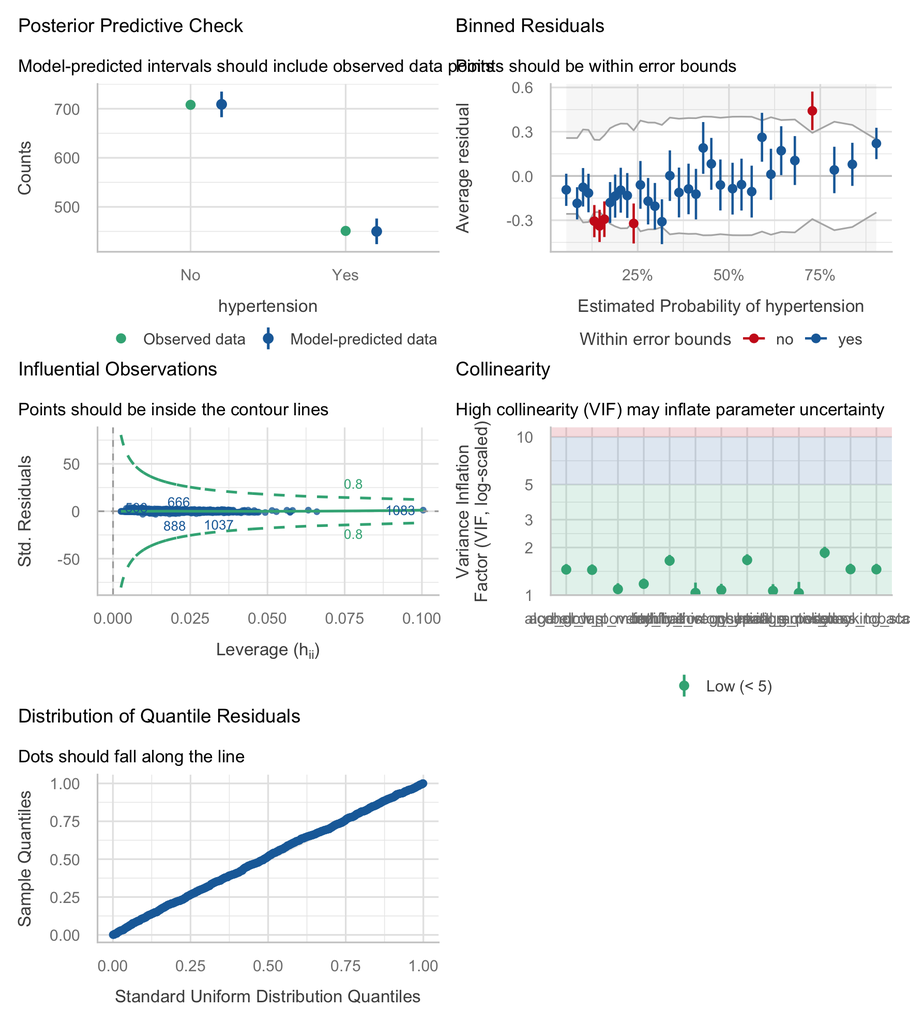

As a demonstration of what the excluded variables would have done: regressing hypertension on `bp_awareness` alone gives a log-odds coefficient of 19.8 with a standard error of 420, that is an odds ratio of the order of 10^8 with an infinitely wide confidence interval – the classic signature of complete separation, and a reminder that this variable is a consequence of the outcome, not a predictor of it.

# Discussion

Roughly two in five adults aged 30 and over in Bharatpur are hypertensive, and after mutual adjustment the drivers are age, body mass index and alcohol, with a protective association for education. The odds of hypertension are 4.5 times higher in those aged 60 or more than in those in their thirties, and each 5 kg/m2 of body mass index multiplies the odds by about 2.23. Recent alcohol use nearly doubles the odds (1.93). What does *not* survive adjustment is equally important for programme design: smokeless tobacco, low physical activity, poverty, unemployment and even family history all look like risk factors crudely and are null once age, sex and BMI are held fixed. Practically, this argues for age- and weight-based screening and for alcohol as the one behavioural target with an independent signal here, rather than a broad lifestyle campaign.

**Limitations.** First, and specific to this outcome, **the composite definition makes several apparently obvious predictors unusable**. `hypertension` is raised measured pressure *or* current treatment, so `systolic_bp`, `diastolic_bp` and `antihypertensive_drug` are components of it and cannot appear on the right-hand side; `bp_awareness` is a consequence of it and separates the outcome perfectly. A student who includes any of them gets an impressive-looking model that means nothing. Second, the composite also mixes two rather different states: 37 participants are classified hypertensive on the basis of medication alone despite normal readings on the day, so the outcome is partly “has been diagnosed and treated” and partly “has a high reading now” – and access to diagnosis and treatment is itself socially patterned, which will bias the education and poverty coefficients in an unknown direction. Third, **the cluster sampling cannot be modelled**: only four wards were randomly selected with roughly 300 participants each, and the sample size calculation assumed a design effect of 1.5, but no ward identifier exists in this extract. All confidence intervals reported here are therefore too narrow, plausibly by around 20%, and no mixed-effects or survey-design correction can repair that; nor can results from four clusters be generalised to Nepal or even to Bharatpur as a whole. Fourth, **age is available only in four bands**, so no odds ratio per year of age is estimable and the oldest band is open-ended. Fifth, the design is cross-sectional, so nothing here is a causal effect: the former-smoker result and the positive fruit-and-vegetable coefficient are both best explained by reverse causation or by behaviour change after diagnosis, and the same mechanism could be operating more subtly for salt and physical activity. Sixth, hypertension was defined on a single visit with two readings, whereas clinical diagnosis requires readings on separate occasions, so some participants are misclassified by white-coat effect. On the credit side, **the file has no missing data at all** (all 1159 rows complete on all 21 variables) and the event count of 451 is generous relative to the number of parameters.

**Future work.** Refit with a ward random effect if the identifier can be obtained; and split the outcome into “raised measured pressure” and “treated” to see whether the socio-economic coefficients differ between the two, which would test the access-to-treatment explanation directly.

# Feasibility notes

*Not part of a student report.*